# Assignment 4, PCA

Zhulin Yu

11/2/2017

```r
library(dplyr)
```

```r
library(tidyr)
library(ggplot2)
library(corrplot)
```

# Part I

Load Data

```r
D1 = read.csv("Assistments-confidence.csv")
D1 = dplyr::select(D1, -c(id))
```

Correlogram Image

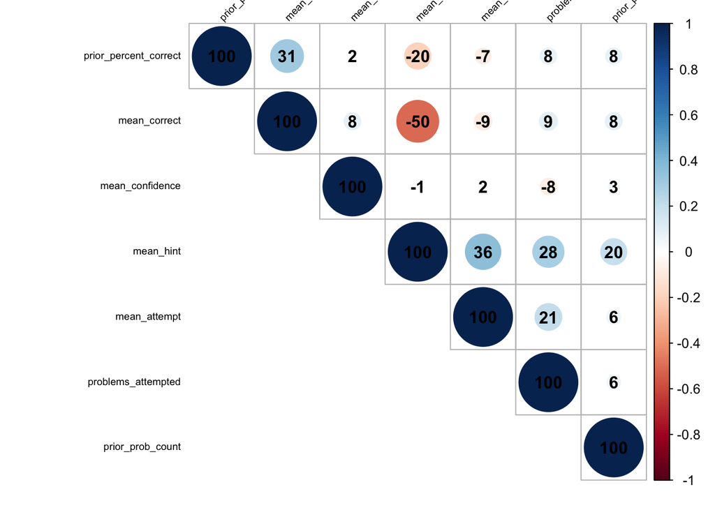

```r
COR <- cor(D1)

corrplot(COR, order="AOE", method="circle", tl.pos="lt", type="upper",
tl.col="black", tl.cex=0.6, tl.srt=45,
        addCoef.col="black", addCoefasPercent = TRUE,
        sig.level=0.50, insig = "blank")
```

```r
#Study your correlogram image and save it, you will need it later
```

Remove mean_correct

```r
D2 <- dplyr::select(D1, -c(mean_correct))

#The, scale and center your data for easier interpretation
D2 <- scale(D2, center = TRUE)
```

Perform PCA

```r
pca <- prcomp(D2, scale = TRUE)
pca$sdev
```

```
## [1] 1.2825140 1.0543565 1.0245688 0.9621486 0.8556715 0.7320146
```

```r
#To convert this into variance accounted for we can square it, these numbers are proportional to the eigenvalue
pca$sdev^2
```

```
## [1] 1.6448423 1.1116675 1.0497412 0.9257299 0.7321737 0.5358454
```

```r
#A summary of our pca will give us the proportion of variance accounted for by each component
print(summary(pca))
```

```
## Importance of components:
##                           PC1    PC2    PC3    PC4    PC5     PC6
## Standard deviation     1.2825 1.0544 1.0246 0.9621 0.8557 0.73201
## Proportion of Variance 0.2741 0.1853 0.1750 0.1543 0.1220 0.08931
## Cumulative Proportion  0.2741 0.4594 0.6344 0.7887 0.9107 1.00000
```

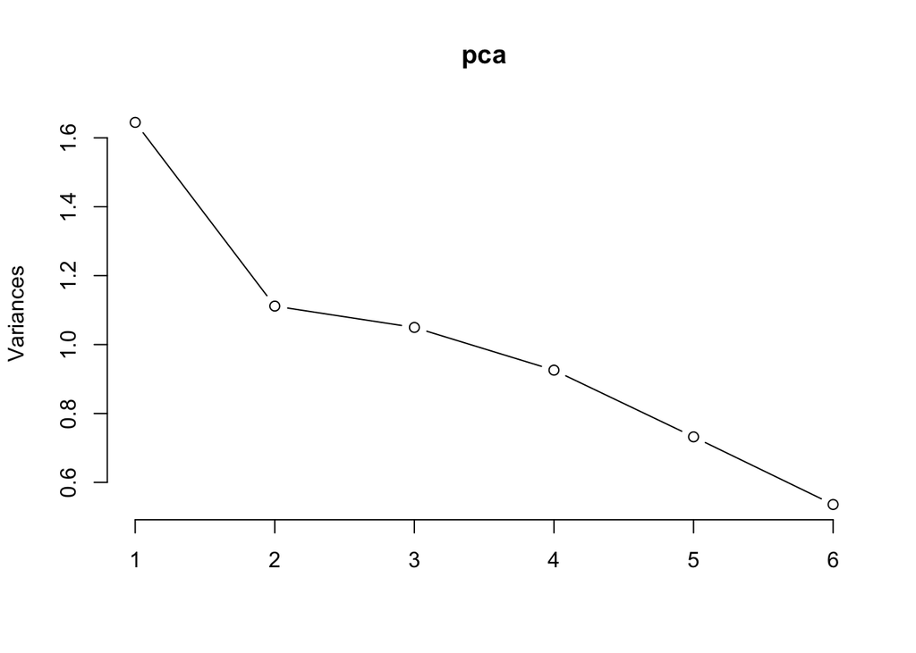

```r
#We can look at this to get an idea of which components we should keep and which we should drop
plot(pca, type = "lines")
```

Check linear combinatino of all PCs

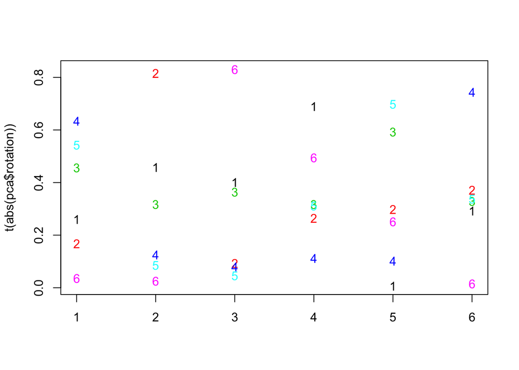

```r
matplot(t(abs(pca$rotation)), type = "p", lty = 1:5, lwd = 1, pch = NULL, col = 1:6)
```

# Part II

Look at transformed data

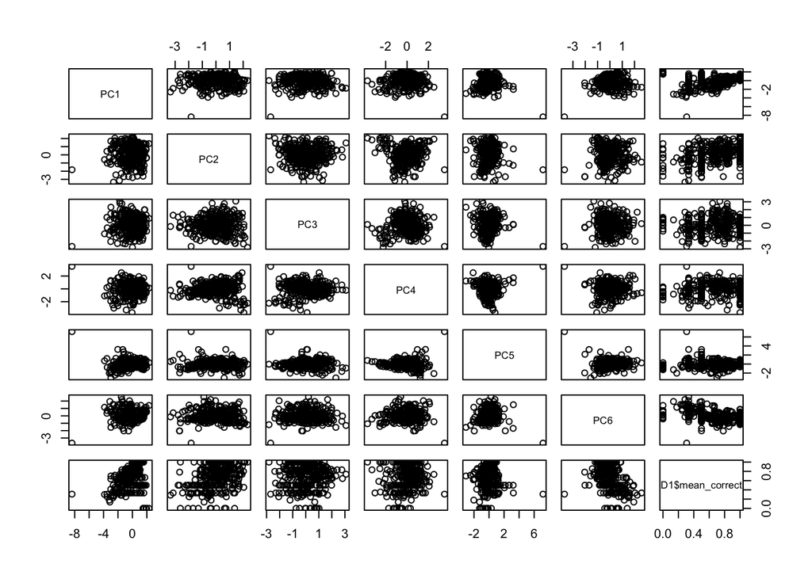

```r
D3 <- as.data.frame(pca$x)

#Attach the variable "mean_correct" from your original data frame to D3.
D4 <- cbind(D3, as.data.frame(D1$mean_correct))

#Now re-run your scatterplots and correlations between the transformed data and mean_correct. If you had dropped some components would you have lost important infomation about mean_correct?

pairs(D4)
```

Correlogram Image for Transformed Data

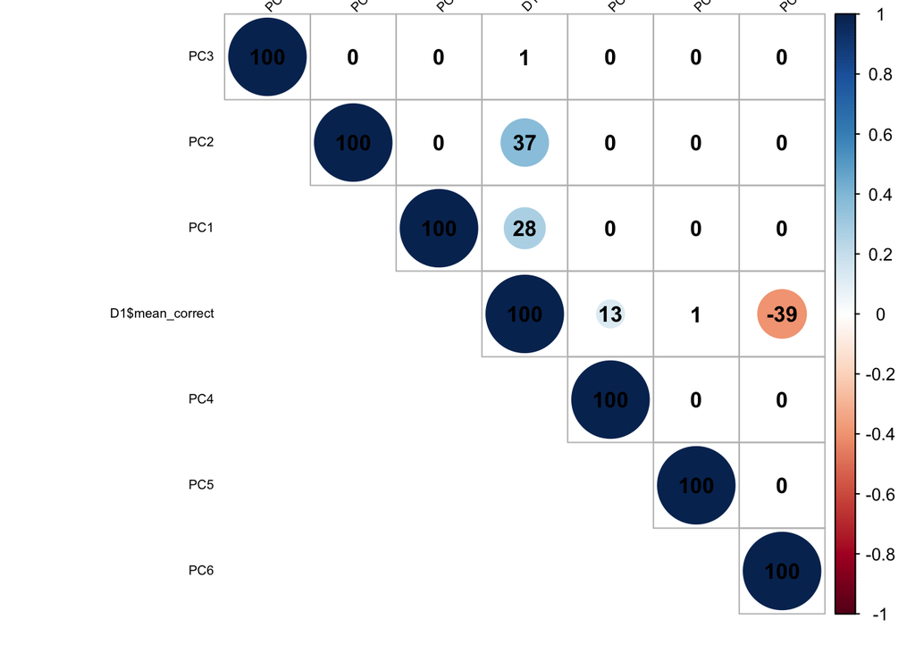

```r
COR2 <- cor(D4)

corrplot(COR2, order="AOE", method="circle", tl.pos="lt", type="upper",
tl.col="black", tl.cex=0.6, tl.srt=45,
        addCoef.col="black", addCoefasPercent = TRUE,
        sig.level=0.050, insig = "blank")
```

```r
fit = lm(D4$`D1$mean_correct` ~ D4$PC1 + D4$PC2 + D4$PC3 + D4$PC4 + D4$PC5 + D4$PC6)
summary(fit)
```

```
##
## Call:
## lm(formula = D4$`D1$mean_correct` ~ D4$PC1 + D4$PC2 + D4$PC3 +
##     D4$PC4 + D4$PC5 + D4$PC6)
##
## Residuals:
##      Min       1Q   Median       3Q      Max
## -0.73754 -0.11293  0.01522  0.13623  0.41012
##
## Coefficients:
##              Estimate Std. Error t value Pr(>|t|)
## (Intercept)  0.671489   0.010899  61.608  < 2e-16 ***
## D4$PC1       0.055460   0.008511   6.516 2.65e-10 ***
## D4$PC2       0.090323   0.010353   8.725  < 2e-16 ***
## D4$PC3       0.001844   0.010654   0.173  0.86267
## D4$PC4       0.033992   0.011345   2.996  0.00294 **
## D4$PC5       0.002169   0.012757   0.170  0.86511
## D4$PC6      -0.136884   0.014911  -9.180  < 2e-16 ***
## ---
## Signif. codes:  0 '***' 0.001 '**' 0.01 '*' 0.05 '.' 0.1 ' ' 1
##
## Residual standard error: 0.2016 on 335 degrees of freedom
## Multiple R-squared:  0.3874, Adjusted R-squared:  0.3765
## F-statistic: 35.31 on 6 and 335 DF,  p-value: < 2.2e-16
```

Drop PC6

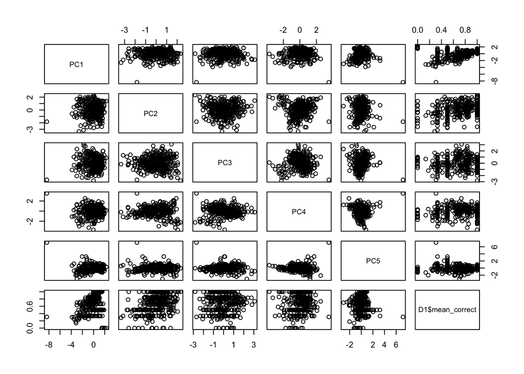

```r
D5 = dplyr::select(D4, -c(PC6))
pairs(D5)
```

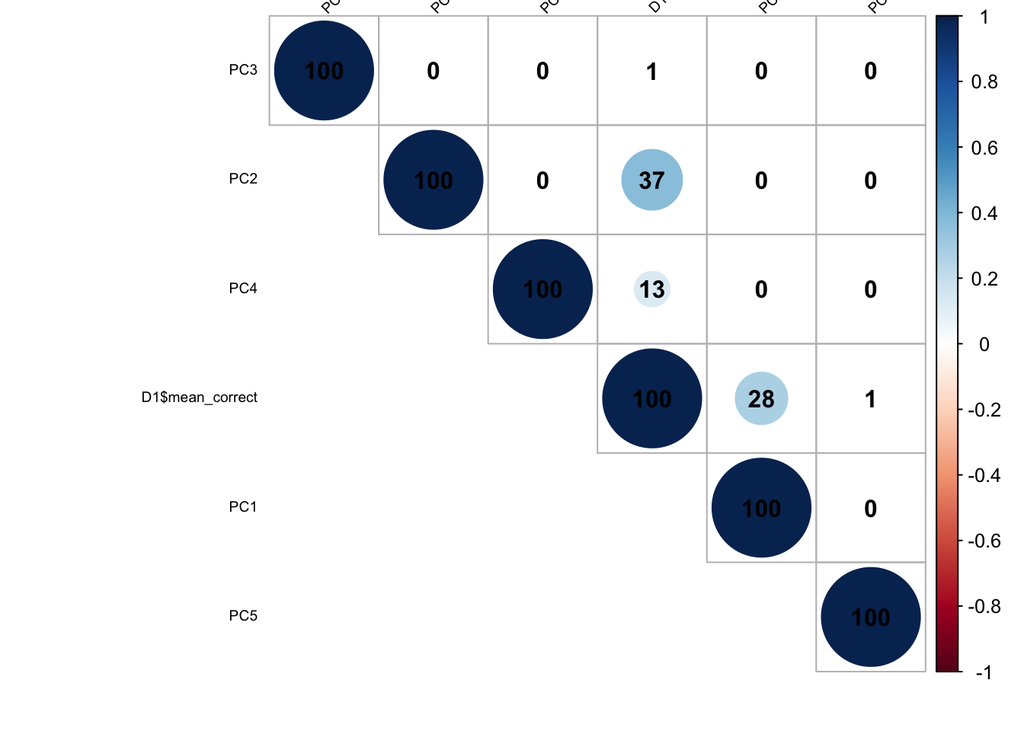

```r
COR3 <- cor(D5)

corrplot(COR3, order="AOE", method="circle", tl.pos="lt", type="upper",
tl.col="black", tl.cex=0.6, tl.srt=45,
        addCoef.col="black", addCoefasPercent = TRUE,
        sig.level=0.050, insig = "blank")
```

```r
fit2 = lm(D5$`D1$mean_correct` ~ D5$PC1 + D5$PC2 + D5$PC3 + D5$PC4 + D5$PC5)
summary(fit2)
```

```
##
## Call:
## lm(formula = D5$`D1$mean_correct` ~ D5$PC1 + D5$PC2 + D5$PC3 +
##     D5$PC4 + D5$PC5)
##
## Residuals:
##      Min       1Q   Median       3Q      Max
## -0.92972 -0.14741  0.03767  0.15665  0.53917
##
## Coefficients:
##             Estimate Std. Error t value Pr(>|t|)
## (Intercept) 0.671489   0.012175  55.152  < 2e-16 ***
## D5$PC1      0.055460   0.009507   5.833 1.28e-08 ***
## D5$PC2      0.090323   0.011565   7.810 7.35e-14 ***
## D5$PC3      0.001844   0.011901   0.155  0.87694
## D5$PC4      0.033992   0.012673   2.682  0.00767 **
## D5$PC5      0.002169   0.014250   0.152  0.87913
## ---
## Signif. codes:  0 '***' 0.001 '**' 0.01 '*' 0.05 '.' 0.1 ' ' 1
##
## Residual standard error: 0.2252 on 336 degrees of freedom
## Multiple R-squared:  0.2334, Adjusted R-squared:  0.2219
## F-statistic: 20.45 on 5 and 336 DF,  p-value: < 2.2e-16
```

Eigenvectors

```r
pca$rotation
```

```
##                               PC1         PC2         PC3        PC4
## prior_prob_count      -0.26034140  0.45818753 -0.40090679 -0.6897642
## prior_percent_correct  0.16840319  0.81617867  0.09267306  0.2640040
## problems_attempted    -0.45568733  0.31685183  0.36387724  0.3168141
## mean_hint             -0.63337594 -0.12501620 -0.08008842 -0.1122586
## mean_attempt          -0.54200011 -0.08510858 -0.04585364  0.3108682
## mean_confidence        0.03581325  0.02547483 -0.83051917  0.4948890
##                                PC5         PC6
## prior_prob_count      -0.007142834 -0.29280482
## prior_percent_correct  0.298843852  0.37134715
## problems_attempted    -0.592336569 -0.32911025
## mean_hint             -0.102302115  0.74412634
## mean_attempt           0.697232132 -0.33781385
## mean_confidence       -0.251357022 -0.01452143
```

```r
#Examine the eigenvectors, notice that they are a little difficult to interpret. It is much easier to make sense of them if we make them proportional within each component

loadings <- abs(pca$rotation) #abs() will make all eigenvectors positive

sweep(loadings, 2, colSums(loadings), "/") #sweep() computes each row as a proportion of the column. (There must be a way to do this with dplyr()?)
```

```
##                              PC1        PC2        PC3        PC4
## prior_prob_count      0.12423113 0.25081186 0.22101700 0.31516257
## prior_percent_correct 0.08035956 0.44677621 0.05108998 0.12062699
## problems_attempted    0.21744737 0.17344469 0.20060288 0.14475664
## mean_hint             0.30223780 0.06843387 0.04415217 0.05129246
## mean_attempt          0.25863458 0.04658844 0.02527878 0.14203987
## mean_confidence       0.01708956 0.01394492 0.45785919 0.22612148
##                               PC5        PC6
## prior_prob_count      0.003664468 0.14011651
## prior_percent_correct 0.153315014 0.17770154
## problems_attempted    0.303884750 0.15748983
## mean_hint             0.052483764 0.35608836
## mean_attempt          0.357699023 0.16165478
## mean_confidence       0.128952980 0.00694897
```

```r
#If using dplyr(), we can first use summarise_each to calculate the column mean and expand the means to a 6x6 matrix
tmp = as.numeric(rep(dplyr::summarise_each(as.data.frame(loadings), funs(sum)), each = 6), nrow = 6)

# And then divide loadings by the column means:
loadings/tmp
```

```
##                              PC1        PC2        PC3        PC4
## prior_prob_count      0.12423113 0.25081186 0.22101700 0.31516257
## prior_percent_correct 0.08035956 0.44677621 0.05108998 0.12062699
## problems_attempted    0.21744737 0.17344469 0.20060288 0.14475664
## mean_hint             0.30223780 0.06843387 0.04415217 0.05129246
## mean_attempt          0.25863458 0.04658844 0.02527878 0.14203987
## mean_confidence       0.01708956 0.01394492 0.45785919 0.22612148
##                               PC5        PC6
## prior_prob_count      0.003664468 0.14011651
## prior_percent_correct 0.153315014 0.17770154
## problems_attempted    0.303884750 0.15748983
## mean_hint             0.052483764 0.35608836
## mean_attempt          0.357699023 0.16165478
## mean_confidence       0.128952980 0.00694897
```

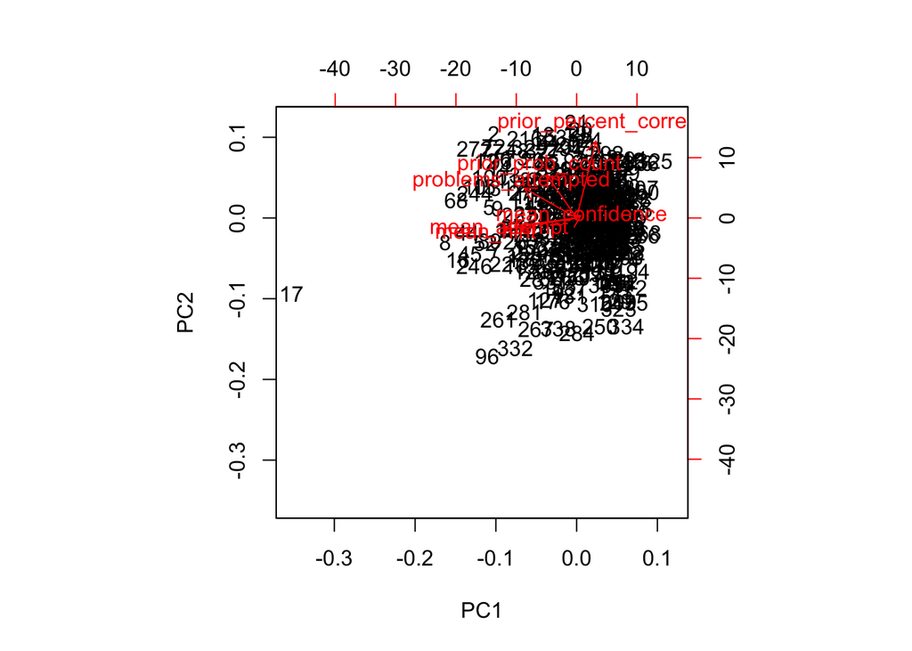

```r
# The result is the same as out of sweep().

#Now examine your components and try to come up with substantive descriptions of what some might represent?

#You can generate a biplot to help you, though these can be a bit confusing. They plot the transformed data by the first two components. Therefore, the axes represent the direction of maximum variance. Then mapped onto this point cloud are the original directions of the variables, depicted as red arrows. It is supposed to provide a visualization of which variables "go together". Variables that possibly represent the same underlying construct point in the same direction.

biplot(pca)
```

```r
# From the plot, we can see that mean_hint and mean_attempt seem to represent the same underlying construct, though we do not know what that is.
```

Calculate values for each student that represent these your composite variables and then create a new correlogram showing their relationship to mean_correct.

```r
# Values for each student that represent the composite variables are the transformed data from the pca result. So their relationship to mean_correct is the correlogram image above. We can see that PC2 is most correlated with mean_correct, followed by PC1 and then PC4. PC3 and PC5 are almost un-correlated with mean_correct at all.
```

# Part III

According to the codebook, all questions are grouped into 4 sections: affiliative, selfenhancing, aggressive, and selfdefeating.

```r
K1 = read.csv("humor_data.csv")
#affiliative = (((6-K1$Q1) + K1$Q5 + (6-K1$Q9) + K1$Q13 + (6-K1$Q17) + K1$Q21 + (6-K1$Q25) + (6-K1$Q29))/8)
#selfenhancing = ((K1$Q2 + K1$Q6 + K1$Q10 + K1$Q14 + K1$Q18 + K1$Q22 + K1$Q26 + K1$Q30)/8)
#aggressive = ((K1$Q3+ K1$Q7 + K1$Q11 + K1$Q15 + K1$Q19 + K1$Q23 + K1$Q27 + K1$Q31)/8)
#selfdefeating = ((K1$Q4 + K1$Q8 + K1$Q12 + K1$Q16 + K1$Q20 + K1$Q24 + K1$Q28 + K1$Q32)/8)
```

I want to validate whether the 32 questions are designed (categorized) reasonably. That is, if performing a PCA on the scores of Q1-Q32, whether these variables form 4 PCs. Since 5 questions are reverse-coded, we convert the scores by distracting from 6.

```r
K2 = K1 %>% select(c(1:32))
K2$Q1 = 6 - K2$Q1
K2$Q9 = 6 - K2$Q9
K2$Q17 = 6 - K2$Q17
K2$Q25 = 6 - K2$Q25
K2$Q29 = 6 - K2$Q29
K2 <- scale(K2, center = TRUE)
```

Perform PCA

```r
pca2 <- prcomp(K2, scale = TRUE)
pca2$sdev
```

```
##  [1] 2.4943111 1.8024083 1.6831741 1.4784656 1.2030427 1.0125176 1.0014851
##  [8] 0.9583264 0.9193296 0.8934064 0.8821141 0.8531886 0.8449333 0.8229371
## [15] 0.7934106 0.7797708 0.7663446 0.7642473 0.7465136 0.7287594 0.7236779
## [22] 0.7120325 0.7065632 0.6914301 0.6781329 0.6578595 0.6531532 0.6458890
## [29] 0.6137997 0.6023745 0.5625567 0.5278429
```

```r
pca2$sdev^2
```

```
##  [1] 6.2215881 3.2486758 2.8330752 2.1858605 1.4473118 1.0251919 1.0029725
##  [8] 0.9183895 0.8451669 0.7981749 0.7781253 0.7279308 0.7139123 0.6772255
## [15] 0.6295003 0.6080425 0.5872840 0.5840739 0.5572825 0.5310902 0.5237097
## [22] 0.5069903 0.4992316 0.4780756 0.4598642 0.4327792 0.4266091 0.4171726
## [29] 0.3767501 0.3628550 0.3164700 0.2786182
```

```r
print(summary(pca2))
```

```
## Importance of components:
##                           PC1    PC2     PC3     PC4     PC5     PC6
## Standard deviation     2.4943 1.8024 1.68317 1.47847 1.20304 1.01252
## Proportion of Variance 0.1944 0.1015 0.08853 0.06831 0.04523 0.03204
## Cumulative Proportion  0.1944 0.2959 0.38448 0.45279 0.49802 0.53005
##                            PC7    PC8     PC9    PC10    PC11    PC12
## Standard deviation     1.00149 0.9583 0.91933 0.89341 0.88211 0.85319
## Proportion of Variance 0.03134 0.0287 0.02641 0.02494 0.02432 0.02275
## Cumulative Proportion  0.56140 0.5901 0.61651 0.64145 0.66577 0.68851
##                           PC13    PC14    PC15   PC16    PC17    PC18
## Standard deviation     0.84493 0.82294 0.79341 0.7798 0.76634 0.76425
## Proportion of Variance 0.02231 0.02116 0.01967 0.0190 0.01835 0.01825
## Cumulative Proportion  0.71082 0.73199 0.75166 0.7707 0.78901 0.80727
##                           PC19   PC20    PC21    PC22   PC23    PC24
## Standard deviation     0.74651 0.7288 0.72368 0.71203 0.7066 0.69143
## Proportion of Variance 0.01742 0.0166 0.01637 0.01584 0.0156 0.01494
## Cumulative Proportion  0.82468 0.8413 0.85764 0.87349 0.8891 0.90403
##                           PC25    PC26    PC27    PC28    PC29    PC30
## Standard deviation     0.67813 0.65786 0.65315 0.64589 0.61380 0.60237
## Proportion of Variance 0.01437 0.01352 0.01333 0.01304 0.01177 0.01134
## Cumulative Proportion  0.91840 0.93192 0.94525 0.95829 0.97006 0.98140
##                           PC31    PC32
## Standard deviation     0.56256 0.52784
## Proportion of Variance 0.00989 0.00871
## Cumulative Proportion  0.99129 1.00000
```

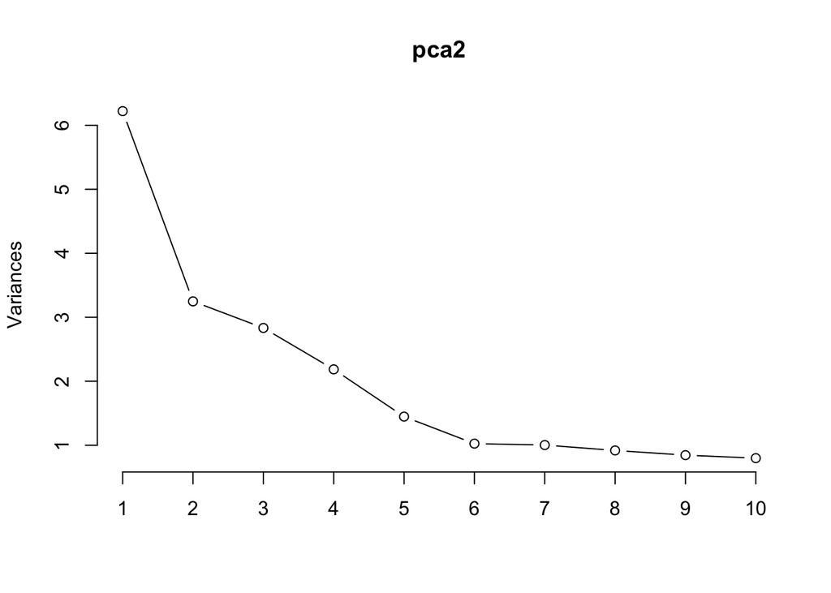

```r
plot(pca2, type = "lines")
```

It seems we could keep the first 6 or even more components.

More importantly, let’s check how the questions are grouped.

We look at the projection of all questions on the first few PCs.

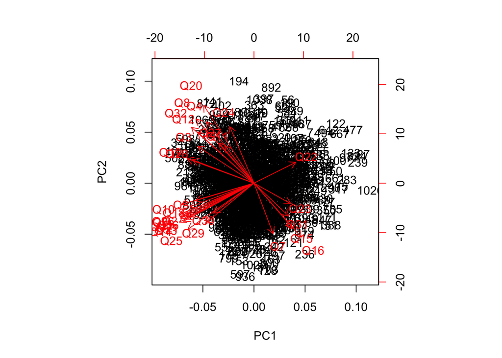

```r
# First, PC1 and PC2
biplot(pca2, choices = c(1,2))
```

We can see four groups of vectors, pointing at different directions (many are hard to identify from plot):

1, Q22

2, Q4, Q8, Q20, Q12, Q32, Q24, …

3, Q9, Q18, Q2, Q6, Q13, Q14, Q26, Q10, Q18, Q9, Q30, Q25, Q29, …

4, Q23, Q31, Q15, Q27, Q16

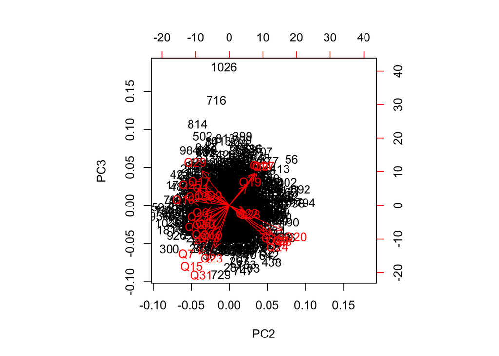

```r
# Then, PC2 and PC3
biplot(pca2, choices = c(2,3))
```

1, Q20, Q24, Q28, Q12, Q32, Q8, …

2, Q11, Q27, Q19, …

4, Q14, Q30, …

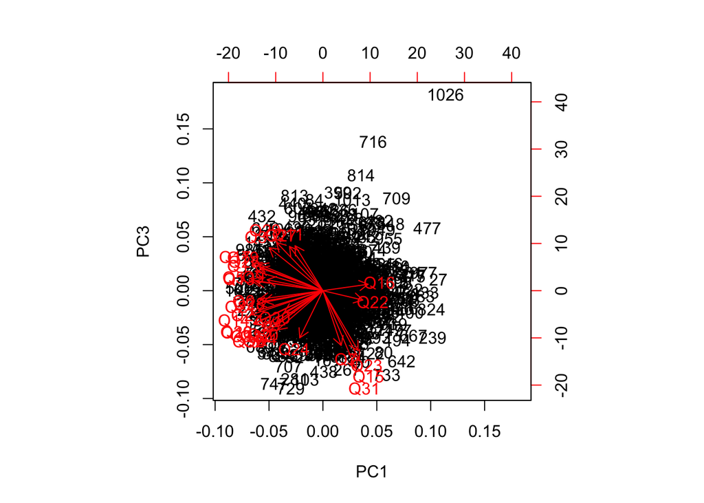

```r
# And PC1 and PC3
biplot(pca2, choices = c(1,3))
```

We also try PC1-PC4, PC2-PC4, etc.

It is always hard to imagine PCs in high-dimensional space. Therefore, we could only draw some implications from the projection. And it seems we do have 4 groups (of vectors, i.e., questions) and many follow the original groups (Q(1,5,9,13,17,21,25,29), Q(2,6,10,14,18,22,26,30), Q(3,7,11,15,19,23,27,31), Q(4,8,12,16,20,24,28,32)), though not identical.